# PShaji_Assignment13

Priya Shaji

11/23/2019

**1. Use integration by substitution to solve the integral below.**

$\int 4e^{-7x} dx$

**Answer 1)**

$z=−7x$

$dx=−17dz$

$4\int e^{z}-1/7 dz$

${-4/7} \int e^z dz$

${-4/7}e^z + C$

${-4/7}e^{-7x} + C$

**2. Biologists are treating a pond contaminated with bacteria. The level of contamination is changing at a rate of $\int dN/dt = -3150/t^4-220$ bacteria per cubic centimeter per day, where t is the number of days since treatment began. Find a function N( t ) to estimate the level of contamination if the level after 1 day was 6530 bacteria per cubic centimeter.**

**Answer 2)**

$\int dN/dt = \int-3150/t^4-220 dt$

$= -12600/t^3 -220t+C$

Given, N(1)=6530 we can use this to find C

$N(1)=6530=-12600/1^3-220(1)+C$

$C=6290$

$N(1)=-12600/t^3-220t+6290$

**3. Find the total area of the red rectangles in the figure below, where the equation of the line is f ( x ) = 2x - 9**

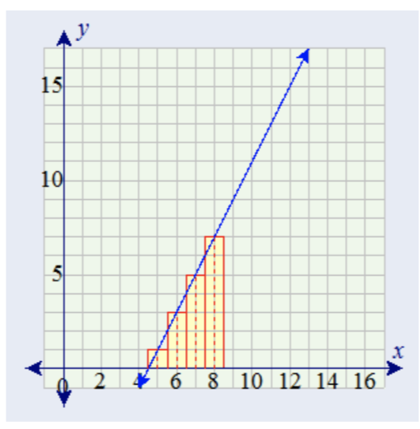

**Answer 3)**

$\int_{4.5}^{8.5} 2x-9x dx$

$x^2-9xdx|_{4.5}^{8.5}$

```r
((8.5)*(8.5)-(9*8.5))-((4.5)*(4.5)-(9*4.5))
```

```
## [1] 16
```

Therefore, the total area of the red rectangles is 16.

**4. Find the area of the region bounded by the graphs of the given equations. $y=x^2-2x-2$, $y=x+2$ Enter your answer below.**

**Answer 4)**

To find the intersections:

$0=x2−3x−4$

$0=(x−4)(x+1)$

So the intersections occur at x=−1 and x=4

The area enclosed by these points has y=x+2 above the other equations. So to find the area:

$\int_{-1}^{4}x^2+2dx−\int_{-1}^{4}x^2−2x−2dx$

$=\int_{-1}^{4}−x^2+3x+4dx$

$=−x^3/3+3x^2/2+4x∣_{-1}^{4}$

$=−64/3+48/2+16−(−1/3+3/2−4)=−63/3+45/2+20$

$=−21+22.5+20$

$=21.5$

**5. A beauty supply store expects to sell 110 flat irons during the next year. It costs $3.75 to store one flat iron for one year. There is a fixed cost of $8.25 for each order. Find the lot size and the number of orders per year that will minimize inventory costs.**

**Answer 5)**

Let x be number of orders/year y be lot size per order

then x * y - total number of irons ordered for the year

x*y >= 110, valid values for x are > = 1 as we need a minimum order of 1 per year to ship the inventory)

By substitution, minimum cost is -

x is number of orders/year = 1 y is lot size per order = 110

```r
inventory_cost = 3.75 * ((110)*(1) - 110) + 8.75*(1)
inventory_cost
```

```
## [1] 8.75
```

**6. Use integration by parts to solve the integral below $\int ln(9x) .x^6 dx$**

**6) Answer**

We will be using integration by parts methods:

$∫u∗dv/dx∗dx = u*v - ∫v∗du/dx∗dx$

$u = ln(9x)$

du/dx, using chain rule -

$u = 9x d/du[ln u * d/dx(9x)] = 1/u* d/dx (9X) = 1/9x * 9$

$du/dx = 1/x$

$dv/dx = x^6$

$v = x^7/7$

$= ln (9x) * x^7/7 - ∫x^7/7∗1/x∗dx= x^7*(ln (9x)/7 - 1)$

**7. Determine whether f ( x ) is a probability density function on the interval [1, e**6 ] . If not, determine the value of the definite integral. $f(x)= 1 /6x$**

**Answer 7)**

$\int_{1}^{e^6} 1/(6x)$

$1/6 *ln x$ from $[1, e^6]$

```r
prob_density = (1/6) * log(exp(6)) - ((1/6) * log(1))
prob_density
```

```
## [1] 1
```

f (x) is a probability density function on the interval $[1, e^6]$ - with the area of the curve as 1 (100% probabily for the interval)